# Análisis Calidad de Vino

# Informacion General - Calidad de Vino

## Conociendo mi base de datos

### Principales Características

La BD brindada consta de las siguientes características:

```r
summary(BDwine)
```

```
 fixed.acidity    volatile.acidity  citric.acid     residual.sugar
 Min.   : 3.800   Min.   :0.0800   Min.   :0.0000   Min.   : 0.600
 1st Qu.: 6.300   1st Qu.:0.2100   1st Qu.:0.2700   1st Qu.: 1.700
 Median : 6.800   Median :0.2600   Median :0.3200   Median : 5.200
 Mean   : 6.855   Mean   :0.2782   Mean   :0.3342   Mean   : 6.391
 3rd Qu.: 7.300   3rd Qu.:0.3200   3rd Qu.:0.3900   3rd Qu.: 9.900
 Max.   :14.200   Max.   :1.1000   Max.   :1.6600   Max.   :65.800
   chlorides       free.sulfur.dioxide total.sulfur.dioxide
 Min.   :0.00900   Min.   :  2.00      Min.   :  9.0
 1st Qu.:0.03600   1st Qu.: 23.00      1st Qu.:108.0
 Median :0.04300   Median : 34.00      Median :134.0
 Mean   :0.04577   Mean   : 35.31      Mean   :138.4
 3rd Qu.:0.05000   3rd Qu.: 46.00      3rd Qu.:167.0
 Max.   :0.34600   Max.   :289.00      Max.   :440.0
    density             pH          sulphates         alcohol
 Min.   :0.9871   Min.   :2.720   Min.   :0.2200   Min.   : 8.00
 1st Qu.:0.9917   1st Qu.:3.090   1st Qu.:0.4100   1st Qu.: 9.50
 Median :0.9937   Median :3.180   Median :0.4700   Median :10.40
 Mean   :0.9940   Mean   :3.188   Mean   :0.4898   Mean   :10.51
 3rd Qu.:0.9961   3rd Qu.:3.280   3rd Qu.:0.5500   3rd Qu.:11.40
 Max.   :1.0390   Max.   :3.820   Max.   :1.0800   Max.   :14.20
    quality
 Min.   :3.000
 1st Qu.:5.000
 Median :6.000
 Mean   :5.878
 3rd Qu.:6.000
 Max.   :9.000
```

```r
str(BDwine)
```

```
'data.frame':   4898 obs. of  12 variables:
 $ fixed.acidity       : num  7 6.3 8.1 7.2 7.2 8.1 6.2 7 6.3 8.1 ...
 $ volatile.acidity    : num  0.27 0.3 0.28 0.23 0.23 0.28 0.32 0.27 0.3 0.22 ...
 $ citric.acid         : num  0.36 0.34 0.4 0.32 0.32 0.4 0.16 0.36 0.34 0.43 ...
 $ residual.sugar      : num  20.7 1.6 6.9 8.5 8.5 6.9 7 20.7 1.6 1.5 ...
 $ chlorides           : num  0.045 0.049 0.05 0.058 0.058 0.05 0.045 0.045 0.049 0.044 ...
 $ free.sulfur.dioxide : num  45 14 30 47 47 30 30 45 14 28 ...
 $ total.sulfur.dioxide: num  170 132 97 186 186 97 136 170 132 129 ...
 $ density             : num  1.001 0.994 0.995 0.996 0.996 ...
 $ pH                  : num  3 3.3 3.26 3.19 3.19 3.26 3.18 3 3.3 3.22 ...
 $ sulphates           : num  0.45 0.49 0.44 0.4 0.4 0.44 0.47 0.45 0.49 0.45 ...
 $ alcohol             : num  8.8 9.5 10.1 9.9 9.9 10.1 9.6 8.8 9.5 11 ...
 $ quality             : int  6 6 6 6 6 6 6 6 6 6 ...
```

Se puede apreciar que la BD no contempla valores faltantes o desconocidos, por lo que se prosigue a graficar para el análisis.

### Histograma de la BD según su calidad

La distribución de la BD según su calidad muestra mayor cantidad de vinos entre las calidades 5 y 7, mientras que el resto de calidades tienen menor cantidad

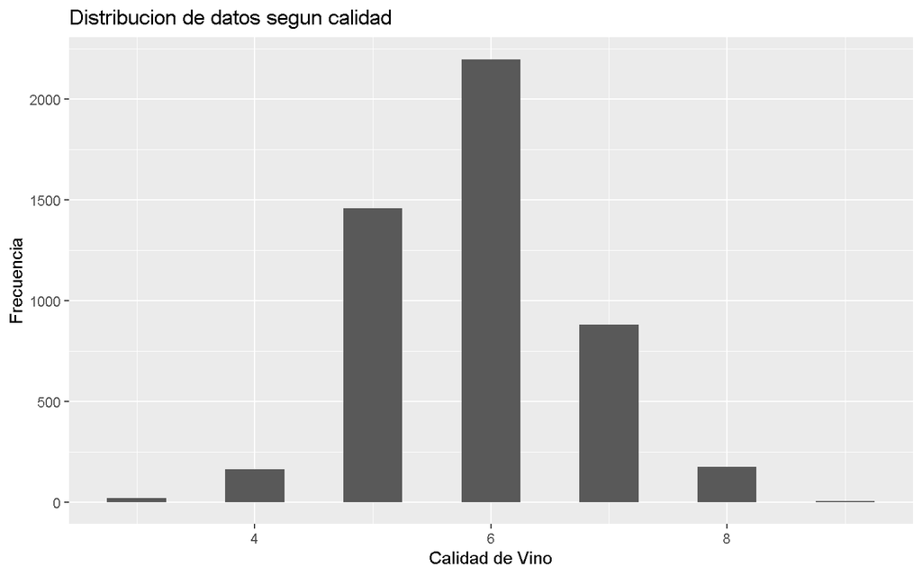

## Correlación entre las variables de la BD

El grafico siguiente muestra la relacion de las variables entre ellas. Se destaca la relacion de:

- Calidad Vs Alcohol
- Densidad Vs Alcohol
- Densidad VS Azucar Residual
- Calidad VS Acidez Fija
- Calidad Vs Acidez Volatil

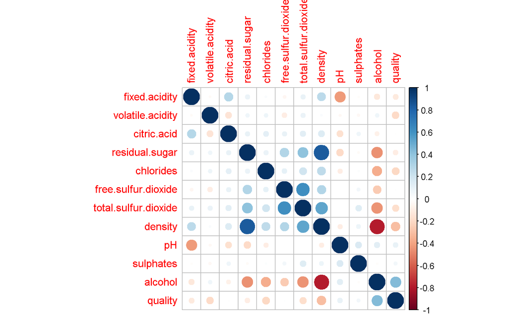

```r
mat.cor = cor(BDwine[-13])
corrplot(mat.cor, method = "circle")
```

# Reclasificacion de Datos

Para un mejor estudio de la BD, estos se agruparán en tres principales secciones según la calidad de vino.

## Nueva Varible Classify

La clasificación se guardará en una variable llamada *Classify*

```r
BDwine$Classify = ifelse(BDwine$quality >= 8, "Alta", ifelse(BDwine$quality <=
    3, "Baja", "Media"))
summary(BDwine$Classify)
```

```
   Length     Class      Mode
     4898 character character
```

```r
str(BDwine$Classify)
```

```
 chr [1:4898] "Media" "Media" "Media" "Media" "Media" "Media" "Media" ...
```

### Análisis por Calidad Clasificación

Se realiza un análisis de las correlaciones de Densidad y Alcohol según su clasificación de calidad.

- Podemos deducir que los vino con calidad más alta tienen en su mayoría un alto grado de alcohol y por lo tanto menor densidad
- La densidad y el grado de alcohol de los vinos de calidad Baja son muy dispersos por lo que no se puede realizar una deducción
- Los vino con calidad Media tienen datos picos fuera de la media

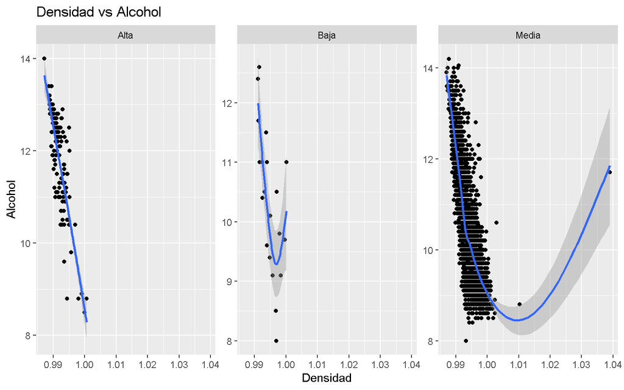

## Partición de la BD

Para un mejor analisis segmentado, se separa la BD en tres Dataframe, Alto, Medio y Bajo

```
 fixed.acidity   volatile.acidity  citric.acid     residual.sugar
 Min.   :3.900   Min.   :0.120    Min.   :0.0400   Min.   : 0.800
 1st Qu.:6.200   1st Qu.:0.200    1st Qu.:0.2800   1st Qu.: 2.075
 Median :6.800   Median :0.260    Median :0.3200   Median : 4.300
 Mean   :6.678   Mean   :0.278    Mean   :0.3282   Mean   : 5.628
 3rd Qu.:7.300   3rd Qu.:0.330    3rd Qu.:0.3600   3rd Qu.: 8.150
   chlorides       free.sulfur.dioxide total.sulfur.dioxide
 Min.   :0.01400   Min.   :  6.00      Min.   : 59.0
 1st Qu.:0.03000   1st Qu.: 28.00      1st Qu.:102.8
 Median :0.03550   Median : 34.50      Median :122.0
 Mean   :0.03801   Mean   : 36.63      Mean   :125.9
 3rd Qu.:0.04400   3rd Qu.: 44.25      3rd Qu.:148.5
    density             pH          sulphates         alcohol
 Min.   :0.9871   Min.   :2.940   Min.   :0.2500   Min.   : 8.50
 1st Qu.:0.9903   1st Qu.:3.127   1st Qu.:0.3800   1st Qu.:11.00
 Median :0.9916   Median :3.230   Median :0.4600   Median :12.00
 Mean   :0.9922   Mean   :3.221   Mean   :0.4857   Mean   :11.65
 3rd Qu.:0.9935   3rd Qu.:3.330   3rd Qu.:0.5825   3rd Qu.:12.60
    quality        Classify
 Min.   :8.000   Length:180
 1st Qu.:8.000   Class :character
 Median :8.000   Mode  :character
 Mean   :8.028
 3rd Qu.:8.000
 [ reached getOption("max.print") -- omitted 1 row ]
```

```
 fixed.acidity    volatile.acidity  citric.acid     residual.sugar
 Min.   : 3.800   Min.   :0.080    Min.   :0.0000   Min.   : 0.600
 1st Qu.: 6.300   1st Qu.:0.210    1st Qu.:0.2700   1st Qu.: 1.700
 Median : 6.800   Median :0.260    Median :0.3200   Median : 5.200
 Mean   : 6.858   Mean   :0.278    Mean   :0.3344   Mean   : 6.421
 3rd Qu.: 7.300   3rd Qu.:0.320    3rd Qu.:0.3900   3rd Qu.: 9.900
   chlorides       free.sulfur.dioxide total.sulfur.dioxide
 Min.   :0.00900   Min.   :  2.00      Min.   :  9.0
 1st Qu.:0.03600   1st Qu.: 23.00      1st Qu.:109.0
 Median :0.04300   Median : 34.00      Median :135.0
 Mean   :0.04603   Mean   : 35.18      Mean   :138.7
 3rd Qu.:0.05000   3rd Qu.: 46.00      3rd Qu.:168.0
    density             pH          sulphates         alcohol
 Min.   :0.9871   Min.   :2.720   Min.   :0.2200   Min.   : 8.00
 1st Qu.:0.9918   1st Qu.:3.080   1st Qu.:0.4100   1st Qu.: 9.40
 Median :0.9938   Median :3.180   Median :0.4800   Median :10.30
 Mean   :0.9941   Mean   :3.187   Mean   :0.4901   Mean   :10.47
 3rd Qu.:0.9962   3rd Qu.:3.280   3rd Qu.:0.5500   3rd Qu.:11.30
    quality        Classify
 Min.   :4.000   Length:4698
 1st Qu.:5.000   Class :character
 Median :6.000   Mode  :character
 Mean   :5.808
 3rd Qu.:6.000
 [ reached getOption("max.print") -- omitted 1 row ]
```

```
 fixed.acidity    volatile.acidity  citric.acid     residual.sugar
 Min.   : 4.200   Min.   :0.1700   Min.   :0.2100   Min.   : 0.700
 1st Qu.: 6.575   1st Qu.:0.2375   1st Qu.:0.2575   1st Qu.: 1.587
 Median : 7.300   Median :0.2600   Median :0.3450   Median : 4.600
 Mean   : 7.600   Mean   :0.3332   Mean   :0.3360   Mean   : 6.393
 3rd Qu.: 8.525   3rd Qu.:0.4125   3rd Qu.:0.3850   3rd Qu.:10.700
   chlorides       free.sulfur.dioxide total.sulfur.dioxide
 Min.   :0.02200   Min.   :  5.00      Min.   : 19.0
 1st Qu.:0.03625   1st Qu.: 13.25      1st Qu.:105.8
 Median :0.04100   Median : 33.50      Median :159.5
 Mean   :0.05430   Mean   : 53.33      Mean   :170.6
 3rd Qu.:0.05400   3rd Qu.: 47.50      3rd Qu.:210.0
    density             pH          sulphates         alcohol
 Min.   :0.9911   Min.   :2.870   Min.   :0.2800   Min.   : 8.00
 1st Qu.:0.9925   1st Qu.:3.035   1st Qu.:0.3800   1st Qu.: 9.55
 Median :0.9944   Median :3.215   Median :0.4400   Median :10.45
 Mean   :0.9949   Mean   :3.188   Mean   :0.4745   Mean   :10.35
 3rd Qu.:0.9969   3rd Qu.:3.325   3rd Qu.:0.5425   3rd Qu.:11.00
    quality    Classify
 Min.   :3   Length:20
 1st Qu.:3   Class :character
 Median :3   Mode  :character
 Mean   :3
 3rd Qu.:3
 [ reached getOption("max.print") -- omitted 1 row ]
```

# Análisis por variable

Una vez tengo la BD partida, puedo realizar un análisis con cada una de estas para un análisis detallado

## Calidad Alta

Para los vinos de calidad alta que cuentan con mayor alcohol tiene menor grado de densidad.

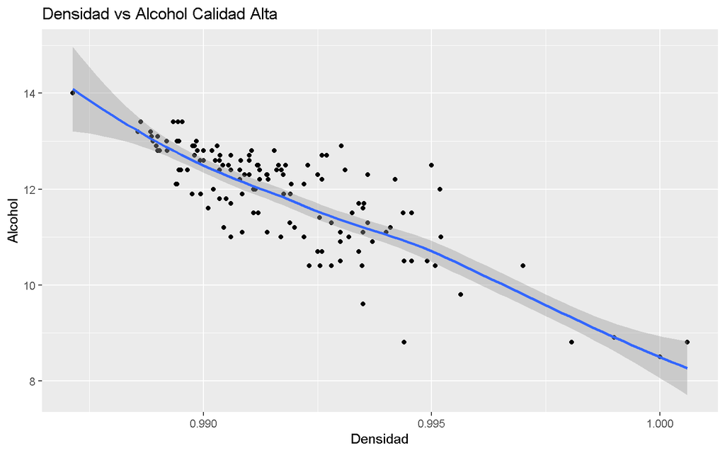

## Calidad Baja

En caso de los vinos de calidad Baja, grado de alcohol de estos es muy variado, por lo que su grado de densidad también es muy variada.

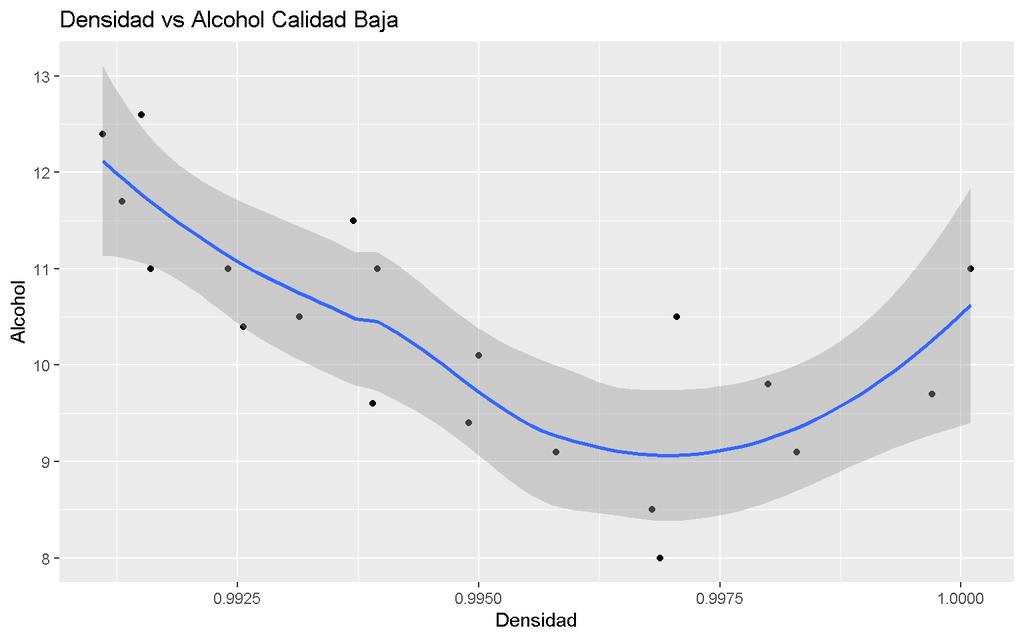

## Calidad Media

Los vinos de calidad media, tienen un comportamiento de a mayor alcohol menor densidad del vino. Sin embargo existen vinos de esa calidad que cuentan con grados de densida superiores a 1, siendo picos de toda la BD

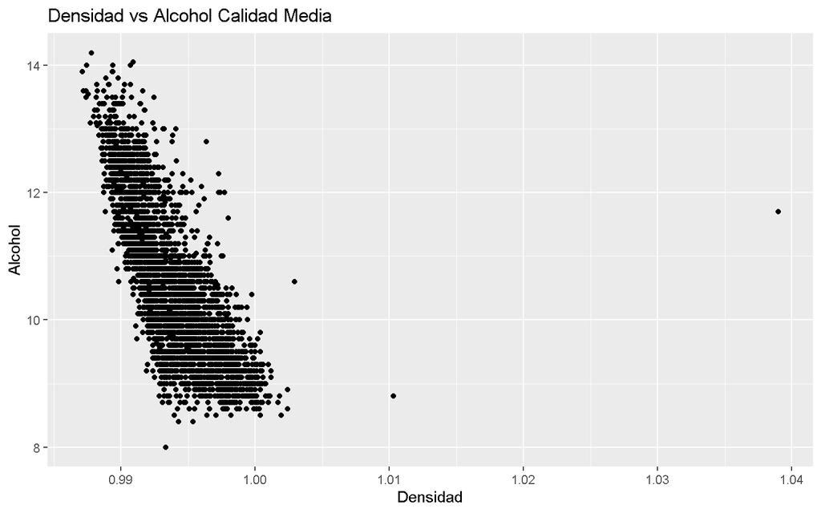

# Relacion entre variables por Calidad

Se estudiará la relación de las diferentes de variables Vs Calidad segmentado por la variable *Classify*

## Calidad vs Alcohol

Para el gráfico siguiente, los vinos con calidad alta tiene mayor grado de alcohol que el resto de vinos

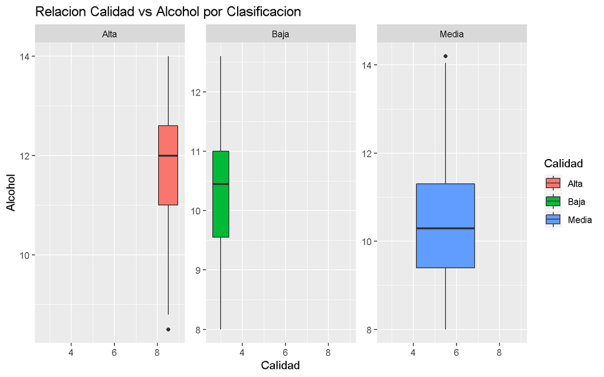

## Calidad vs Total Dioxido de Sulfuro

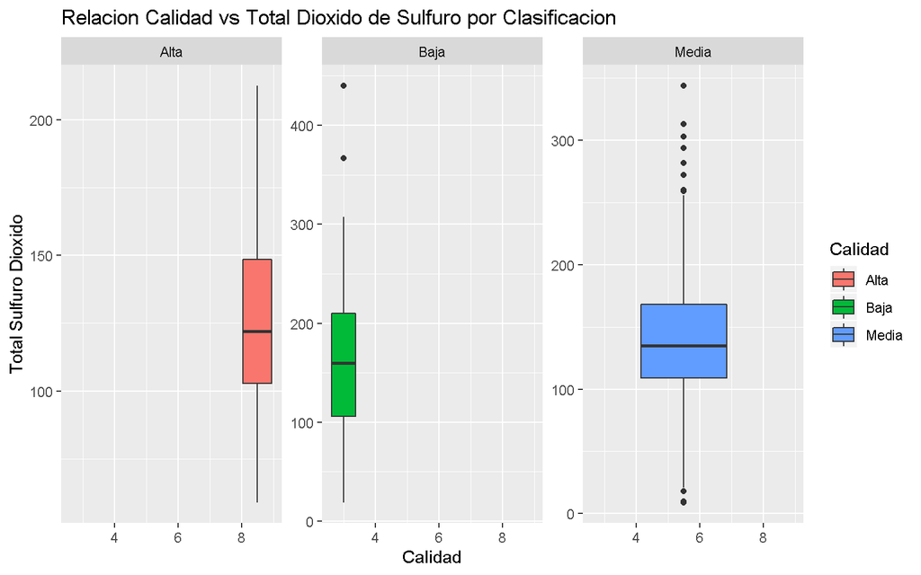

## Calidad vs Volatile Acidity

Los vinos de calidad baja y calidad media tienen en promedio la misma concentración de Volatile Acidity. Sin embargo, la calidad baja tiene mayores valores de Volatile Acidity

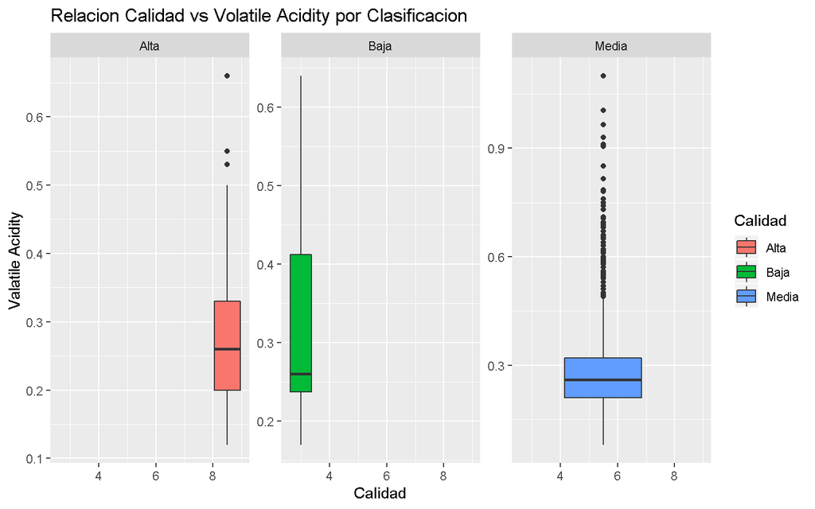

## Calidad vs Fixed Acidity

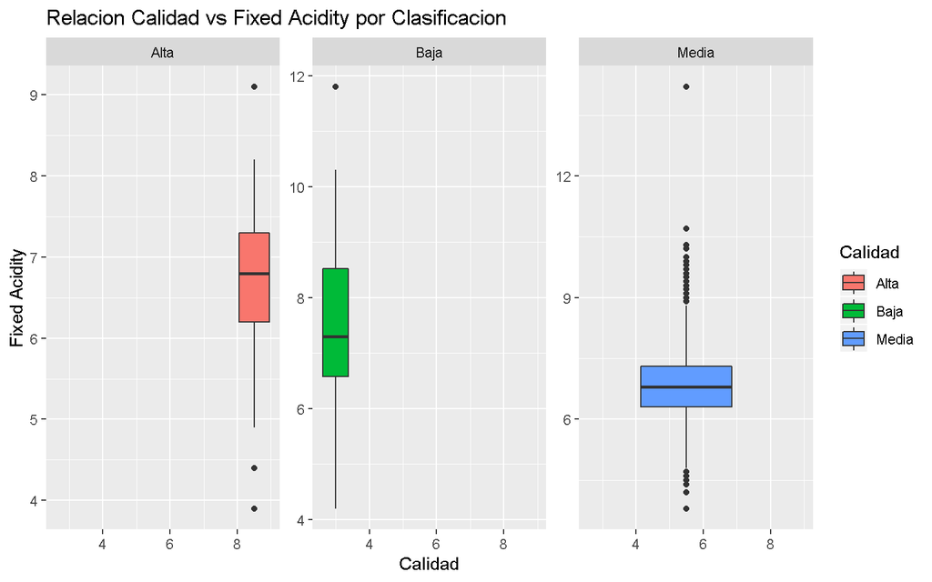

# Analisis a fondo de la calidad Media

Debido a la cantidad de datos en el rango de calidad media, es necesario realizar un análisis de solo la Calidad Media.

## Distribución de datos Calidad Media

La mayor cantidad de datos con clasificación media tienen una calidad de 6

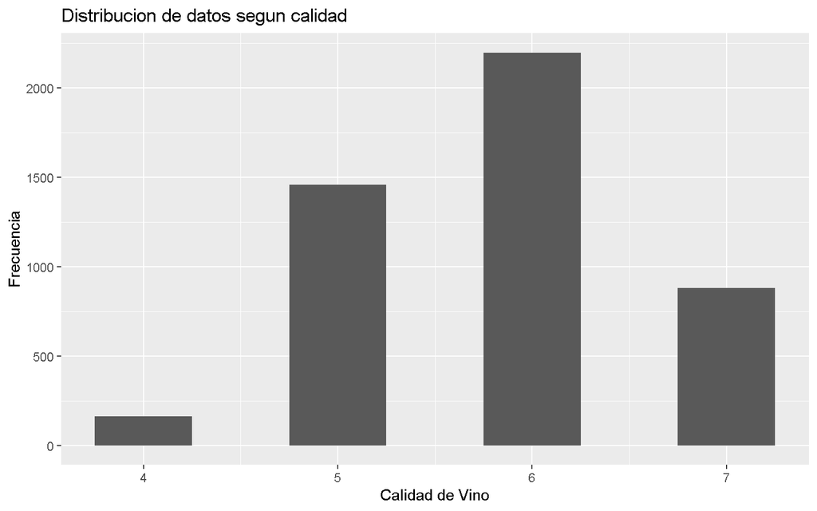

## Relación Densidad Vs Alcohol

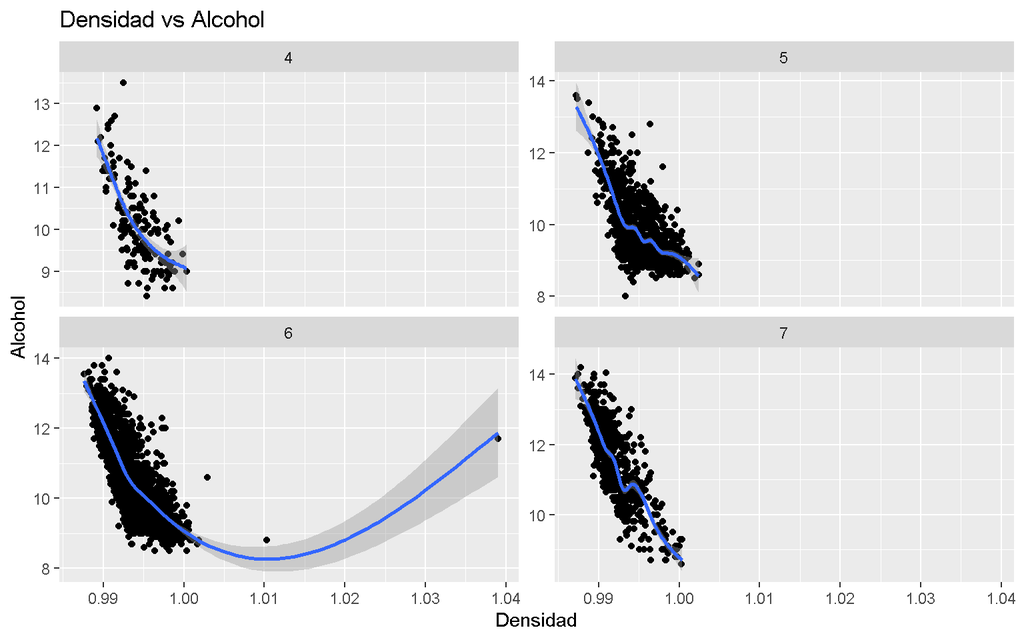

## Calidad vs Fixed Acidity

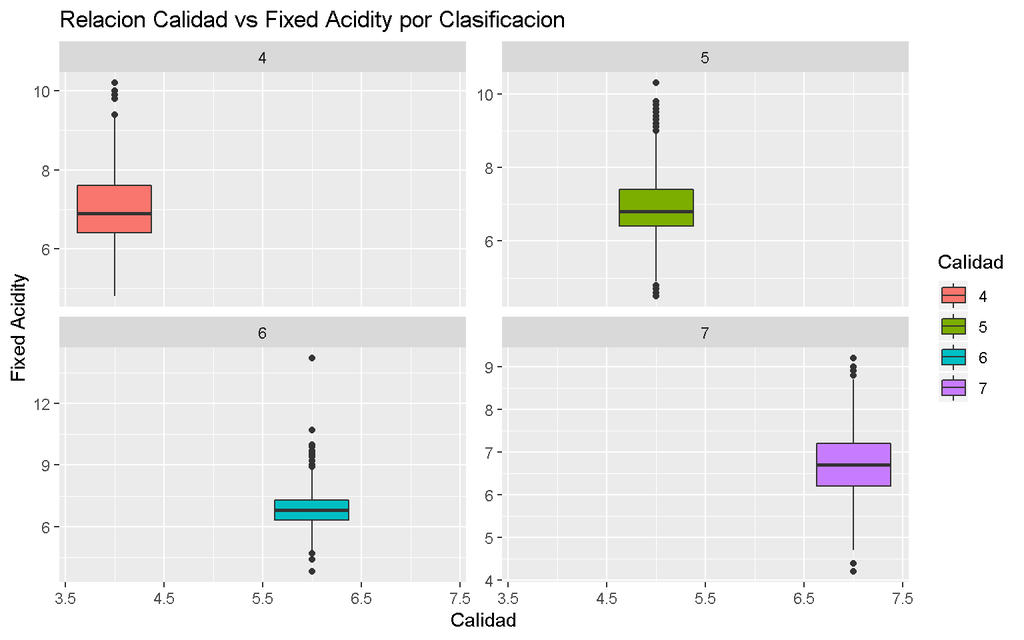

Ing. Ana Munoz Maquera